# Practice Code: Day 7

Author

Constantin Manuel Bosancianu

Published

August 6, 2019

# 1 Introduction

We rely on two separate data sets today, each with its own characteristics. The first data comes from a sleep study.

```r
library(pacman)
p_load(tidyverse, ggeffects, texreg, arm, broom.mixed,
       ggthemes, broom, nlme, HLMdiag, knitr,
       kableExtra, magrittr)
```

We also define here the standard centering function we’ve been using so far.

```r
fun_two_SD <- function(x) {
        (x - mean(x, na.rm = TRUE)) / (2 * sd(x, na.rm = TRUE))
}
```

# 2 Sleep study

The data was first introduced by Belenky et al. (2003). A number of 66 volunteers were subjected to sleep deprivation in varying doses over 10 days. In our analyses here we concentrate on the 18 subjects who slept only 3 hours per night for 7 days. All subjects were allowed a period of recovery of 3 days of normal sleep (8 hours a night) following the 7 days.

Throughout the 10 days (7 x 3 hours per night, 3 x 8 hours per night) their reaction times were tested on a psychomotor vigilance test (a visual stimulus would be displayed and the subject’s reaction time to it was measured).

The data is already made available in the `lme4` package, so all we need to do it load it from there.

```r
data("sleepstudy")

sleepstudy %>%
    glimpse()
```

```
Rows: 180
Columns: 3
$ Reaction <dbl> 249.5600, 258.7047, 250.8006, 321.4398, 356.8519, 414.6901, 3…
$ Days     <dbl> 0, 1, 2, 3, 4, 5, 6, 7, 8, 9, 0, 1, 2, 3, 4, 5, 6, 7, 8, 9, 0…
$ Subject  <fct> 308, 308, 308, 308, 308, 308, 308, 308, 308, 308, 309, 309, 3…
```

We’ll only use this data for basic graphical examinations, and to test very simple *unconditional means* and *unconditional growth* models. Little more is possible, as there are no predictors to be found in the data.

The great benefit of working with smaller data sets is that we can rely more on graphical tools - these are vital in the context of longitudinal modeling in helping us understand the trajectories of change.

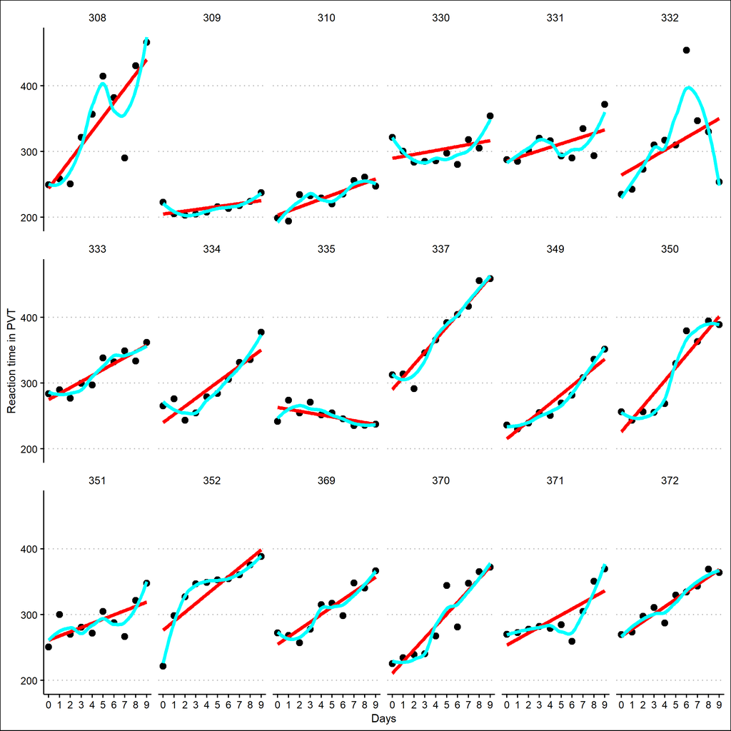

```r
ggplot(data = sleepstudy,
       aes(x = Days,
           y = Reaction)) +
    theme_clean() +
    geom_point(size = 2.5) +
    geom_smooth(method = "lm",
                linewidth = 1.5,
                color = "red",
                se = FALSE) +
    geom_smooth(method = "loess",
                linewidth = 1.5,
                color = "cyan",
                se = FALSE) +
    facet_wrap(. ~ Subject, ncol = 6) +
    labs(x = "Days",
         y = "Reaction time in PVT") +
    scale_x_continuous(breaks = c(0, 1, 2, 3, 4,
                                  5, 6, 7, 8, 9),
                       labels = c("0", "1", "2",
                                  "3", "4", "5",
                                  "6", "7", "8", "9"))
```

**Quick task**: Can you use a snipped of code I was using when plotting varying slopes, and display on each panel the average response time in the entire cohort of 18 subjects? (a horizontal line)

Visually, we can tell there’s a lot of variation across the 10 days of the experiment. Can we also get a measure of how much within-individual variation exists, as a share of total variation?

## 2.1 Unconditional means

For this, we need the *unconditional means* specification. I continue the estimation as we did so far, in the `lme4` package, though this will only get us so far today.

```r
mlm.0 <- lmer(Reaction ~ 1 + (1 | Subject),
              data = sleepstudy)
summary(mlm.0)
```

```
Linear mixed model fit by REML ['lmerMod']
Formula: Reaction ~ 1 + (1 | Subject)
   Data: sleepstudy

REML criterion at convergence: 1904.3

Scaled residuals:
    Min      1Q  Median      3Q     Max
-2.4983 -0.5501 -0.1476  0.5123  3.3446

Random effects:
 Groups   Name        Variance Std.Dev.
 Subject  (Intercept) 1278     35.75
 Residual             1959     44.26
Number of obs: 180, groups:  Subject, 18

Fixed effects:
            Estimate Std. Error t value
(Intercept)   298.51       9.05   32.98
```

The ICC from the model can easily be computed as $1278/(1278 + 1959)$. How do you interpret the ICC in the context of a longitudinal growth model?

## 2.2 Unconditional growth

Let’s move to the *unconditional growth* model. This is going to formalize what the first plot told us: (1) how do the initial score and rate of change in the response time change for individuals, but also (2) what the average baseline score and rate of change is in the sample.

```r
mlm.1 <- lmer(Reaction ~ 1 + Days + (1 + Days | Subject),
              data = sleepstudy)
summary(mlm.1)
```

```
Linear mixed model fit by REML ['lmerMod']
Formula: Reaction ~ 1 + Days + (1 + Days | Subject)
   Data: sleepstudy

REML criterion at convergence: 1743.6

Scaled residuals:
    Min      1Q  Median      3Q     Max
-3.9536 -0.4634  0.0231  0.4634  5.1793

Random effects:
 Groups   Name        Variance Std.Dev. Corr
 Subject  (Intercept) 612.10   24.741
          Days         35.07    5.922   0.07
 Residual             654.94   25.592
Number of obs: 180, groups:  Subject, 18

Fixed effects:
            Estimate Std. Error t value
(Intercept)  251.405      6.825  36.838
Days          10.467      1.546   6.771

Correlation of Fixed Effects:
     (Intr)
Days -0.138
```

What is the average baseline response time in the sample on the first day of the experiment? What’s the average rate of change in this response time for the sample?

**Quick task**: Can you plot how the estimated rate of growth varies for each individual in the sample? Use the code I used in the past few days to plot varying slopes between countries.

## 2.3 Residuals inspection

How do the residuals look in this model?

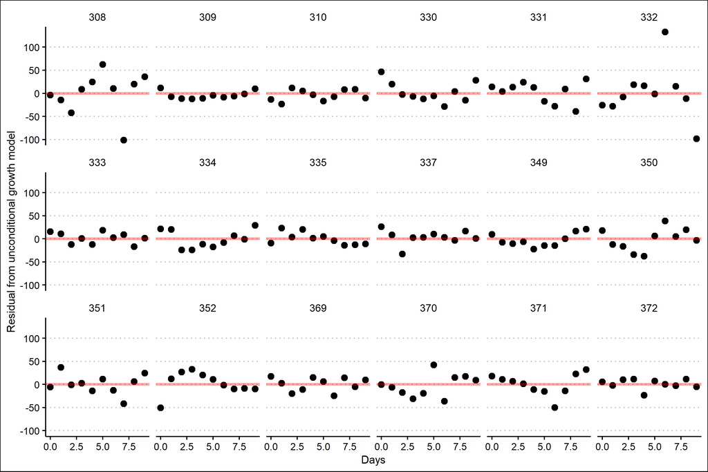

```r
df_resid <- hlm_resid(mlm.1,
                      level = 1)

ggplot(data = df_resid,
       aes(x = Days,
           y = .resid)) +
    theme_clean() +
    geom_point(size = 2.5) +
    geom_hline(yintercept = 0,
               color = "red",
               linewidth = 1.25,
               alpha = 0.35) +
    facet_wrap(. ~ Subject, ncol = 6) +
    labs(x = "Days",
         y = "Residual from unconditional growth model")
```

```r
rm(df_resid)
```

The errors seem to exhibit a AR pattern to them. Sadly, we can’t do much about it in `lme4`, as the ability to specify a custom variance-covariance structure for the L1 errors is not really available. The current principal developer on the package, Ben Bolker, walks through a few of the workarounds here (https://bbolker.github.io/mixedmodels-misc/notes/corr_braindump.html)[^1], but I can’t say either option from there is truly satisfactory for us.

<sup>1</sup> Last accessed on February 1, 2023.

This is why we need to turn to the `nlme` package. Though not as frequently maintained as in the past, `nlme` is still more flexible than `lme4` when it comes to the modeling options it allows for. Compared to `lme4` the syntax is a bit different, but not by much.

## 2.4 `nlme` implementation

```r
mlm.1 <- lme(fixed = Reaction ~ 1 + Days,
             random = ~ 1 + Days | Subject,
             data = sleepstudy,
             method = "REML")
summary(mlm.1)
```

```
Linear mixed-effects model fit by REML
  Data: sleepstudy
       AIC      BIC    logLik
  1755.628 1774.719 -871.8141

Random effects:
 Formula: ~1 + Days | Subject
 Structure: General positive-definite, Log-Cholesky parametrization
            StdDev    Corr
(Intercept) 24.740241 (Intr)
Days         5.922103 0.066
Residual    25.591843

Fixed effects:  Reaction ~ 1 + Days
                Value Std.Error  DF  t-value p-value
(Intercept) 251.40510  6.824516 161 36.83853       0
Days         10.46729  1.545783 161  6.77151       0
 Correlation:
     (Intr)
Days -0.138

Standardized Within-Group Residuals:
        Min          Q1         Med          Q3         Max
-3.95355735 -0.46339976  0.02311783  0.46339621  5.17925089

Number of Observations: 180
Number of Groups: 18
```

Notice how the random effects are reported. What are the similarities and what are the differences compared to `lmer()`?

In this new package, on which we will rely for the rest of today’s session, we can even specify the form of the variance-covariance matrix for the residuals.

```r
mlm.2 <- lme(fixed = Reaction ~ 1 + Days,
             random = ~ 1 | Subject,
             data = sleepstudy,
             method = "REML",
             correlation = corAR1(form = ~ 1 | Subject),
             control = lmeControl(maxIter = 10000,
                                  msMaxIter = 10000))
summary(mlm.2)
```

```
Linear mixed-effects model fit by REML
  Data: sleepstudy
       AIC    BIC    logLik
  1746.191 1762.1 -868.0955

Random effects:
 Formula: ~1 | Subject
        (Intercept) Residual
StdDev:    31.71358 37.63734

Correlation Structure: AR(1)
 Formula: ~1 | Subject
 Parameter estimate(s):
      Phi
0.6531333
Fixed effects:  Reaction ~ 1 + Days
                Value Std.Error  DF   t-value p-value
(Intercept) 252.84144  10.94093 161 23.109688       0
Days         10.46687   1.34408 161  7.787388       0
 Correlation:
     (Intr)
Days -0.553

Standardized Within-Group Residuals:
        Min          Q1         Med          Q3         Max
-2.29962859 -0.60227821  0.01915279  0.46779739  3.85644270

Number of Observations: 180
Number of Groups: 18
```

```r
anova(mlm.1, mlm.2)
```

```
      Model df      AIC      BIC    logLik   Test  L.Ratio p-value
mlm.1     1  6 1755.628 1774.719 -871.8141
mlm.2     2  5 1746.191 1762.100 -868.0955 1 vs 2 7.437208  0.0064
```

```r
rm(mlm.0, mlm.1, mlm.2, sleepstudy)
```

The model with the correlation structure specified clearly fits the data better.

# 3 Employment outcomes study

The data comes from the National Longitudinal Study of Youth in the US, and tracks the employment outcomes of male high-school dropouts in the 1990s. It has the kind of structure that is frequently encountered in practice: irregular spacing between measurement rounds, and measurements performed at irregular dates within a wave.

## 3.1 Read data

```r
link <- "https://stats.idre.ucla.edu/stat/r/examples/alda/data/wages_pp.txt"
df_wages <- read.table(file = link,
                       header = TRUE,
                       sep = ",")

head(df_wages)
```

```
  id   lnw exper ged postexp black hispanic hgc hgc.9 uerate   ue.7 ue.centert1
1 31 1.491 0.015   1   0.015     0        1   8    -1  3.215 -3.785        0.00
2 31 1.433 0.715   1   0.715     0        1   8    -1  3.215 -3.785        0.00
3 31 1.469 1.734   1   1.734     0        1   8    -1  3.215 -3.785        0.00
4 31 1.749 2.773   1   2.773     0        1   8    -1  3.295 -3.705        0.08
5 31 1.931 3.927   1   3.927     0        1   8    -1  2.895 -4.105       -0.32
6 31 1.709 4.946   1   4.946     0        1   8    -1  2.495 -4.505       -0.72
  ue.mean ue.person.cen   ue1
1   3.215          0.00 3.215
2   3.215          0.00 3.215
3   3.215          0.00 3.215
4   3.215          0.08 3.215
5   3.215         -0.32 3.215
6   3.215         -0.72 3.215
```

Data structure:

1. `id`: person ID
2. `lnw`: natural log of wages, in constant 1990 USD ($log_e(wages)$)
3. `exper`: years in labor force to nearest day
4. `ged`: indicator (1 = attained GED; 0 otherwise) (the GED is a test that checks whether a person has skills at the level of a high-school graduate in the US or Canada - it can replace a high-school degree from these countries)
5. `postexp`: years in labor force from day of GED attainment
6. `black`: racial background (1 = black; 0 = otherwise)
7. `hispanic`: hispanic indicator (1 = hispanic; 0 = otherwise)
8. `hgc`: highest grade completed
9. `hgc.9`: highest grade completed, centered on grade 9
10. `uerate`: unemployment rate in the local geographical area
11. `ue.7`: unemployment rate, centered on 7%
12. `ue.centert1`: unemployment rate, centered around the unemployment value at $t_1$
13. `ue.mean`: within-person mean of unemployment rate
14. `ue.person.cen`: unemployment rate, within-person centering
15. `ue.1`: unemployment rate at $t_1$

```r
df_agg <- df_wages %>%
     group_by(id) %>%
     summarise(N = n())

table(df_agg$N) %>%
    as.data.frame() %>%
    kable(caption = "Number of observations by individual",
          caption.above = TRUE,
          col.names = c("Times measured", "N individuals"),
          row.names = FALSE)
```

Number of observations by individual

| Times measured | N individuals |
| --- | --- |
| 1 | 38 |
| 2 | 39 |
| 3 | 47 |
| 4 | 35 |
| 5 | 74 |
| 6 | 92 |
| 7 | 103 |
| 8 | 123 |
| 9 | 127 |
| 10 | 113 |
| 11 | 65 |
| 12 | 26 |
| 13 | 6 |

```r
rm(df_agg)
```

Individual measurement occasions vary between IDs. Some individuals are reached for more than 8 or 9 times, whereas a few are reached 3 times or fewer.

**Quick task**: Select from the data set a random sample of 48 individuals, and plot their observations in a panel grid of 6 rows and 8 columns. Put `exper` on the X axis, and `lnw` on the Y axis. For each panel, fit a linear fit line, so as to examine the trend in wages over time.

## 3.2 Unconditional growth

We can start the modeling from the unconditional growth model.

```r
mlm.1 <- lme(fixed = lnw ~ 1 + exper,
             random = ~ 1 + exper | id,
             data = df_wages,
             method = "ML")
summary(mlm.1)
```

```
Linear mixed-effects model fit by maximum likelihood
  Data: df_wages
       AIC     BIC    logLik
  4933.394 4973.98 -2460.697

Random effects:
 Formula: ~1 + exper | id
 Structure: General positive-definite, Log-Cholesky parametrization
            StdDev     Corr
(Intercept) 0.23295546 (Intr)
exper       0.04154474 -0.301
Residual    0.30839044

Fixed effects:  lnw ~ 1 + exper
                Value   Std.Error   DF   t-value p-value
(Intercept) 1.7156039 0.010798216 5513 158.87846       0
exper       0.0456807 0.002341936 5513  19.50555       0
 Correlation:
      (Intr)
exper -0.565

Standardized Within-Group Residuals:
        Min          Q1         Med          Q3         Max
-4.20113329 -0.52073079 -0.03159151  0.44063198  7.03696498

Number of Observations: 6402
Number of Groups: 888
```

Compared to the previous example, though, we now have an individual-level, time-invariant predictor: a person’s racial background.

```r
df_agg <- df_wages %>%
    group_by(id) %>%
    summarise(black_sd = sd(black, na.rm = TRUE))
table(df_agg$black_sd)
```

```
  0
850
```

```r
rm(df_agg)
```

**Question**: What is another way in which you can check if a variable truly is measured at the L2 or not?

```r
mlm.2 <- lme(fixed = lnw ~ 1 + exper + black,
             random = ~ 1 + exper | id,
             data = df_wages,
             method = "ML")
summary(mlm.2)
```

```
Linear mixed-effects model fit by maximum likelihood
  Data: df_wages
       AIC      BIC    logLik
  4933.584 4980.935 -2459.792

Random effects:
 Formula: ~1 + exper | id
 Structure: General positive-definite, Log-Cholesky parametrization
            StdDev     Corr
(Intercept) 0.23364038 (Intr)
exper       0.04152842 -0.309
Residual    0.30839183

Fixed effects:  lnw ~ 1 + exper + black
                 Value   Std.Error   DF   t-value p-value
(Intercept)  1.7232421 0.012215962 5513 141.06479  0.0000
exper        0.0455894 0.002342262 5513  19.46382  0.0000
black       -0.0270743 0.020006859  886  -1.35325  0.1763
 Correlation:
      (Intr) exper
exper -0.519
black -0.465  0.036

Standardized Within-Group Residuals:
        Min          Q1         Med          Q3         Max
-4.20633734 -0.51732244 -0.03213205  0.43795484  7.03337675

Number of Observations: 6402
Number of Groups: 888
```

```r
anova(mlm.1, mlm.2)
```

```
      Model df      AIC      BIC    logLik   Test  L.Ratio p-value
mlm.1     1  6 4933.394 4973.980 -2460.697
mlm.2     2  7 4933.584 4980.935 -2459.792 1 vs 2 1.810058  0.1785
```

## 3.3 Expanding model

```r
mlm.3 <- lme(fixed = lnw ~ 1 + exper + black + black * exper,
             random = ~ 1 + exper | id,
             data = df_wages,
             method = "ML")
summary(mlm.3)
```

```
Linear mixed-effects model fit by maximum likelihood
  Data: df_wages
       AIC      BIC    logLik
  4925.064 4979.179 -2454.532

Random effects:
 Formula: ~1 + exper | id
 Structure: General positive-definite, Log-Cholesky parametrization
            StdDev     Corr
(Intercept) 0.23294190 (Intr)
exper       0.04080522 -0.302
Residual    0.30841876

Fixed effects:  lnw ~ 1 + exper + black + black * exper
                 Value   Std.Error   DF   t-value p-value
(Intercept)  1.7120996 0.012671608 5512 135.11305  0.0000
exper        0.0497042 0.002644974 5512  18.79193  0.0000
black        0.0173503 0.024235999  886   0.71589  0.4742
exper:black -0.0179923 0.005527623 5512  -3.25497  0.0011
 Correlation:
            (Intr) exper  black
exper       -0.567
black       -0.523  0.296
exper:black  0.271 -0.479 -0.565

Standardized Within-Group Residuals:
        Min          Q1         Med          Q3         Max
-4.19901731 -0.52432461 -0.03179397  0.44433308  7.03650498

Number of Observations: 6402
Number of Groups: 888
```

```r
anova(mlm.2, mlm.3)
```

```
      Model df      AIC      BIC    logLik   Test  L.Ratio p-value
mlm.2     1  7 4933.584 4980.935 -2459.792
mlm.3     2  8 4925.064 4979.179 -2454.532 1 vs 2 10.52017  0.0012
```

This last specification looks a lot like types of models that we tried in the last week in course. How would you interpret, in the context of a longitudinal model:

1. the effect of `exper`?
2. the effect of `black`?
3. the effect of the cross-level interaction?

We can improve on the specification above by adding another factor: unemployment in the local geographic area, centered around the value of 7%.

```r
mlm.4 <- lme(fixed = lnw ~ 1 + exper + black + black * exper +
                 ue.7,
             random = ~ 1 + exper | id,
             data = df_wages,
             method = "ML")
summary(mlm.4)
```

```
Linear mixed-effects model fit by maximum likelihood
  Data: df_wages
       AIC      BIC    logLik
  4887.161 4948.041 -2434.581

Random effects:
 Formula: ~1 + exper | id
 Structure: General positive-definite, Log-Cholesky parametrization
            StdDev     Corr
(Intercept) 0.23102821 (Intr)
exper       0.04064583 -0.309
Residual    0.30777841

Fixed effects:  lnw ~ 1 + exper + black + black * exper + ue.7
                 Value   Std.Error   DF   t-value p-value
(Intercept)  1.7417036 0.013449284 5511 129.50158  0.0000
exper        0.0447021 0.002753346 5511  16.23556  0.0000
black        0.0047795 0.024188175  886   0.19760  0.8434
ue.7        -0.0114469 0.001808165 5511  -6.33068  0.0000
exper:black -0.0183017 0.005508369 5511  -3.32253  0.0009
 Correlation:
            (Intr) exper  black  ue.7
exper       -0.613
black       -0.517  0.309
ue.7        -0.349  0.289  0.082
exper:black  0.253 -0.456 -0.566  0.009

Standardized Within-Group Residuals:
        Min          Q1         Med          Q3         Max
-4.25655640 -0.52266537 -0.03439262  0.44191766  6.99873843

Number of Observations: 6402
Number of Groups: 888
```